# Lab 4 - EDA

Your name

2022/09/22

Trong bài lab này ta sẽ sử dụng thư viện `dplyr` và `ggplot2` để tóm tắt và trực quan hóa dữ liệu.

### Thư viên `dplyr`

- Thư viện `dplyr` là thư viện chuyên dùng cho biến đổi và tóm tắt dữ liệu. Thư viện này cung cấp một số hàm cơ bản sau:
  - `filter`: lọc theo điều kiện
  - `slice`: chọn các dòng theo chỉ số
  - `select`: chọn cột theo tên
  - `rename`: đổi tên cột
  - `arrange`: sắp xếp dòng theo điều kiện
  - `mutate`: tạo biến (cột) mới
  - `sample_n`, `sample_frac`: chọn ngẫu nhiên một số dòng
  - …
- Ta cần cài đặt và load thư viện này trước khi sử dụng.

```r
#install.packages("dplyr")
library(dplyr)
```

### Toán tử `pipe (%>%)`

- Đây là toán tử dùng để mô tả một chuỗi các thao tác được hỗ trợ bởi thư viện `dplyr`.
- Ví dụ bên dưới sử dụng tập dữ liệu `starwars` để minh họa toán tử `pipe (%>%)`. Đây là tập dữ liệu về các diễn viên đã tham gia phim `Starwars` và có sẵn trong thư viện `dplyr`.

```r
head(starwars)
```

```
## # A tibble: 6 × 14
##   name         height  mass hair_…¹ skin_…² eye_c…³ birth…⁴ sex   gender homew…⁵
##   <chr>         <int> <dbl> <chr>   <chr>   <chr>     <dbl> <chr> <chr>  <chr>
## 1 Luke Skywal…    172    77 blond   fair    blue       19   male  mascu… Tatooi…
## 2 C-3PO           167    75 <NA>    gold    yellow    112   none  mascu… Tatooi…
## 3 R2-D2            96    32 <NA>    white,… red        33   none  mascu… Naboo
## 4 Darth Vader     202   136 none    white   yellow     41.9 male  mascu… Tatooi…
## 5 Leia Organa     150    49 brown   light   brown      19   fema… femin… Aldera…
## 6 Owen Lars       178   120 brown,… light   blue       52   male  mascu… Tatooi…
## # … with 4 more variables: species <chr>, films <list>, vehicles <list>,
## #   starships <list>, and abbreviated variable names ¹hair_color, ²skin_color,
## #   ³eye_color, ⁴birth_year, ⁵homeworld
```

- Đoạn mã sau thực hiện việc nhóm các diễn viên theo **giới tính** và **đếm số lượng** dùng toán tử `pipe (%>%)`.

```r
starwars %>%
  group_by(gender) %>%
  summarise(gender_count = n())
```

```
## # A tibble: 3 × 2
##   gender    gender_count
##   <chr>            <int>
## 1 feminine            17
## 2 masculine           66
## 3 <NA>                 4
```

- Tham khảo thêm cách sử dụng thư viện `dplyr` với toán tử `pipe (%>%)` ở [dplyr documentation](https://dplyr.tidyverse.org/) và [dplyr cheatsheet](https://github.com/rstudio/cheatsheets/blob/main/data-transformation.pdf).

### Thư viện `ggplot2`

- Thư viện `ggplot2` là một trong những thư viện phổ biến nhất cho trực quan hóa dữ liệu. Chữ `gg` trong `ggplot2` là viết tắt của `Grammar of Graphics`.
- Để sử dụng thư viện `ggplot2`, ta cần cài đặt và load nó.

```r
#install.packages("ggplot2")
library(ggplot2)
```

- Trong `ggplot2`, cú pháp để vẽ hình có dạng sau:

```r
ggplot(data = [dataset], mapping = aes(x = [x-variable], y = [y-variable])) +
  geom_xxx() +
  ...
```

- Trong cú pháp trên, `geom_xxx` là loại hình ta muốn vẽ (`geom` là viết tắt của `geometric object`, `xxx` là loại hình như `histogram`, `boxplot`, `line`, …). `ggplot()` là hàm chính của thư viện `ggplot2`.
- Tham khảo thêm cách sử dụng thư viện `ggplot2` ở [ggplot2 documentation](https://ggplot2.tidyverse.org/) và [ggplot2 cheatsheet](https://github.com/rstudio/cheatsheets/raw/master/data-visualization.pdf).

### Load dữ liệu

```r
library(dplyr)
library(ggplot2)
college_recent_grads <- read.csv("recent_grads.csv")
```

- Ta có thể xem qua cấu trúc của tập dữ liệu này dùng hàm `glimpse`.

```r
glimpse(college_recent_grads)
```

```
## Rows: 173
## Columns: 21
## $ Rank                 <int> 1, 2, 3, 4, 5, 6, 7, 8, 9, 10, 11, 12, 13, 14, 15…
## $ Major_code           <int> 2419, 2416, 2415, 2417, 2405, 2418, 6202, 5001, 2…
## $ Major                <chr> "PETROLEUM ENGINEERING", "MINING AND MINERAL ENGI…
## $ Total                <int> 2339, 756, 856, 1258, 32260, 2573, 3777, 1792, 91…
## $ Men                  <int> 2057, 679, 725, 1123, 21239, 2200, 2110, 832, 803…
## $ Women                <int> 282, 77, 131, 135, 11021, 373, 1667, 960, 10907, …
## $ Major_category       <chr> "Engineering", "Engineering", "Engineering", "Eng…
## $ ShareWomen           <dbl> 0.1205643, 0.1018519, 0.1530374, 0.1073132, 0.341…
## $ Sample_size          <int> 36, 7, 3, 16, 289, 17, 51, 10, 1029, 631, 399, 14…
## $ Employed             <int> 1976, 640, 648, 758, 25694, 1857, 2912, 1526, 764…
## $ Full_time            <int> 1849, 556, 558, 1069, 23170, 2038, 2924, 1085, 71…
## $ Part_time            <int> 270, 170, 133, 150, 5180, 264, 296, 553, 13101, 1…
## $ Full_time_year_round <int> 1207, 388, 340, 692, 16697, 1449, 2482, 827, 5463…
## $ Unemployed           <int> 37, 85, 16, 40, 1672, 400, 308, 33, 4650, 3895, 2…
## $ Unemployment_rate    <dbl> 0.018380527, 0.117241379, 0.024096386, 0.05012531…
## $ Median               <int> 110000, 75000, 73000, 70000, 65000, 65000, 62000,…
## $ P25th                <int> 95000, 55000, 50000, 43000, 50000, 50000, 53000, …
## $ P75th                <int> 125000, 90000, 105000, 80000, 75000, 102000, 7200…
## $ College_jobs         <int> 1534, 350, 456, 529, 18314, 1142, 1768, 972, 5284…
## $ Non_college_jobs     <int> 364, 257, 176, 102, 4440, 657, 314, 500, 16384, 1…
## $ Low_wage_jobs        <int> 193, 50, 0, 0, 972, 244, 259, 220, 3253, 3170, 98…
```

- Thông tin về tập dữ liệu như sau:

| Biến | Mô tả |
| --- | --- |
| `Rank` | Xếp hạng theo trung vị của thu nhập (median earnings) |
| `Major_code` | Mã ngành |
| `Major` | Tên chuyên ngành |
| `Major_category` | Nhóm ngành |
| `Total` | Tổng số sinh viên của chuyên ngành |
| `Sample_size` | Kích cỡ mẫu của sinh viên có việc làm toàn thời gian, quanh năm (được sử dụng cho tính thu nhập trung vị) |
| `Men` | Số sinh viên nam |
| `Women` | Số sinh viên nữ |
| `ShareWomen` | Tỷ lệ nữ |
| `Employed` | Số sinh viên có việc làm |
| `Employed_full_time` | Số sinh viên có việc làm toàn thời gian (>= 35 giờ/tuần) |
| `Employed_part_time` | Số sinh viên có việc làm bán thời gian (< 35 giờ/tuần) |
| `Employed_full_time_yearround` | Số sinh viên có việc làm ít nhất 50 tuần và ít nhất 35 giờ/tuần |
| `Unemployed` | Số sinh viên thất nghiệp |
| `Unemployment_rate` | Tỷ lệ sinh viên thất nghiệp, tính bằng Unemployed / (Unemployed + Employed) |
| `Median` | Thu nhập trung vị của lao động toàn thời gian, quanh năm |
| `P25th` | 25th percentile của thu nhập |
| `P75th` | 75th percentile của thu nhập |
| `College_jobs` | Số công việc yêu cầu cần có bằng đại học |
| `Non_college_jobs` | Số công việc không cần có bằng đại học |
| `Low_wage_jobs` | Số lượng công việc lương thấp |

Ta sẽ sử dụng tập dữ liệu trên để trả lời một số câu hỏi sau:

- Ngành nào có tỷ lệ thất nghiệp thấp nhất?
- Ngành nào có tỷ lệ nữ cao nhất?
- So sánh thu nhập trung vị theo nhóm ngành (`major_category`)?
- Sinh viên nữ có khuynh hướng chọn ngành có thu nhâp thấp hay cao?

### Tóm tắt và trực quan hóa dữ liệu

- Để biết nào có tỷ lệ thất nghiệp thấp nhất ta cần sắp xếp dữ liệu. Ta sẽ sử dụng hàm `arrange` để làm việc này, và sắp xếp theo `unemployment_rate`. Mặc định hàm `arrange` sắp xếp theo thứ thự tăng dần.

```r
Unemployment_rate_acs <- college_recent_grads %>%
  arrange(Unemployment_rate)
head(Unemployment_rate_acs)
```

```
##   Rank Major_code                                      Major Total  Men Women
## 1   53       4005           MATHEMATICS AND COMPUTER SCIENCE   609  500   109
## 2   74       3801                      MILITARY TECHNOLOGIES   124  124     0
## 3   84       3602                                     BOTANY  1329  626   703
## 4  113       1106                               SOIL SCIENCE   685  476   209
## 5  121       2301 EDUCATIONAL ADMINISTRATION AND SUPERVISION   804  280   524
## 6   15       2409  ENGINEERING MECHANICS PHYSICS AND SCIENCE  4321 3526   795
##                        Major_category ShareWomen Sample_size Employed Full_time
## 1             Computers & Mathematics  0.1789819           7      559       584
## 2 Industrial Arts & Consumer Services  0.0000000           4        0       111
## 3              Biology & Life Science  0.5289691           9     1010       946
## 4     Agriculture & Natural Resources  0.3051095           4      613       488
## 5                           Education  0.6517413           5      703       733
## 6                         Engineering  0.1839852          30     3608      2999
##   Part_time Full_time_year_round Unemployed Unemployment_rate Median P25th
## 1         0                  391          0       0.000000000  42000 30000
## 2         0                  111          0       0.000000000  40000 40000
## 3       169                  740          0       0.000000000  37000 26000
## 4       185                  383          0       0.000000000  35000 18500
## 5         0                  504          0       0.000000000  34000 29000
## 6       811                 2004         23       0.006334343  58000 25000
##   P75th College_jobs Non_college_jobs Low_wage_jobs
## 1 78000          452               67            25
## 2 40000            0                0             0
## 3 40000          677              184            56
## 4 44000          355              144             0
## 5 35000          346              206           111
## 6 74000         2439              947           263
```

- Để chọn các biến muốn hiển thị và thay đổi thứ tự các biến ta dùng hàm `select`. Ta dễ dạng mở rộng kết quả của đoạn mã trên bằng cách thêm một bước xử lý nữa với **toán tử pipe** (`pipe operator`): `%>%`

```r
Rank_Major_Unemployment_rate <- college_recent_grads %>%
  arrange(Unemployment_rate) %>%
  select(Rank, Major, Unemployment_rate)
head(Rank_Major_Unemployment_rate)
```

```
##   Rank                                      Major Unemployment_rate
## 1   53           MATHEMATICS AND COMPUTER SCIENCE       0.000000000
## 2   74                      MILITARY TECHNOLOGIES       0.000000000
## 3   84                                     BOTANY       0.000000000
## 4  113                               SOIL SCIENCE       0.000000000
## 5  121 EDUCATIONAL ADMINISTRATION AND SUPERVISION       0.000000000
## 6   15  ENGINEERING MECHANICS PHYSICS AND SCIENCE       0.006334343
```

- Ta có thể làm tròn tỷ lệ thất nghiệp theo số thập phân sau dấu phẩy dùng hàm `round`. Đoạn mã dưới dùng hàm `mutate` để tạo biến mới tên `Unemployment_rate` với giá trị được làm tròn 4 số thập phân sau dấu phẩy và ghi đè lại biến `Unemployment_rate` cũ.

```r
Rank_Major_Mutate_Unemployment_rate <- college_recent_grads %>%
  arrange(Unemployment_rate) %>%
  select(Rank, Major, Unemployment_rate) %>%
  mutate(Unemployment_rate = round(Unemployment_rate, digits = 4))
head(Rank_Major_Mutate_Unemployment_rate)
```

```
##   Rank                                      Major Unemployment_rate
## 1   53           MATHEMATICS AND COMPUTER SCIENCE            0.0000
## 2   74                      MILITARY TECHNOLOGIES            0.0000
## 3   84                                     BOTANY            0.0000
## 4  113                               SOIL SCIENCE            0.0000
## 5  121 EDUCATIONAL ADMINISTRATION AND SUPERVISION            0.0000
## 6   15  ENGINEERING MECHANICS PHYSICS AND SCIENCE            0.0063
```

#### **Câu 1.** Viết mã để trả lời câu hỏi này và chỉ hiện thị top 10 ngành đầu tiên (dùng `head(x,10)` để hiển thị 10 kết quả đầu tiên của biến `x`) gồm các thông tin `Rank`, `Major`, và `ShareWomen`.

- Để sắp xếp lại dữ liệu theo thứ tự giảm dần theo `ShareWomen`, có thể dùng lệnh `arrange(desc(ShareWomen))`.

```r
# Viết code xử lý ở đây
#a <- arrange(desc(Rank))
#b <- arrange(desc(Major))
#c <- arrange(desc(ShareWomen))
cau1 <- college_recent_grads %>%
  arrange(desc(ShareWomen)) %>%
  select(Rank, Major, ShareWomen)
head(cau1,10)
```

```
##    Rank                                         Major ShareWomen
## 1   165                     EARLY CHILDHOOD EDUCATION  0.9689537
## 2   164 COMMUNICATION DISORDERS SCIENCES AND SERVICES  0.9679981
## 3    52                    MEDICAL ASSISTING SERVICES  0.9278072
## 4   139                          ELEMENTARY EDUCATION  0.9237455
## 5   151                  FAMILY AND CONSUMER SCIENCES  0.9109326
## 6   101                       SPECIAL NEEDS EDUCATION  0.9066773
## 7   157     HUMAN SERVICES AND COMMUNITY ORGANIZATION  0.9055899
## 8   152                                   SOCIAL WORK  0.9040745
## 9    35                                       NURSING  0.8960190
## 10   89      MISCELLANEOUS HEALTH MEDICAL PROFESSIONS  0.8812939
```

#### **Câu 2.** Vẽ biểu đồ tần số của thu nhập trung vị (biến `Median`)

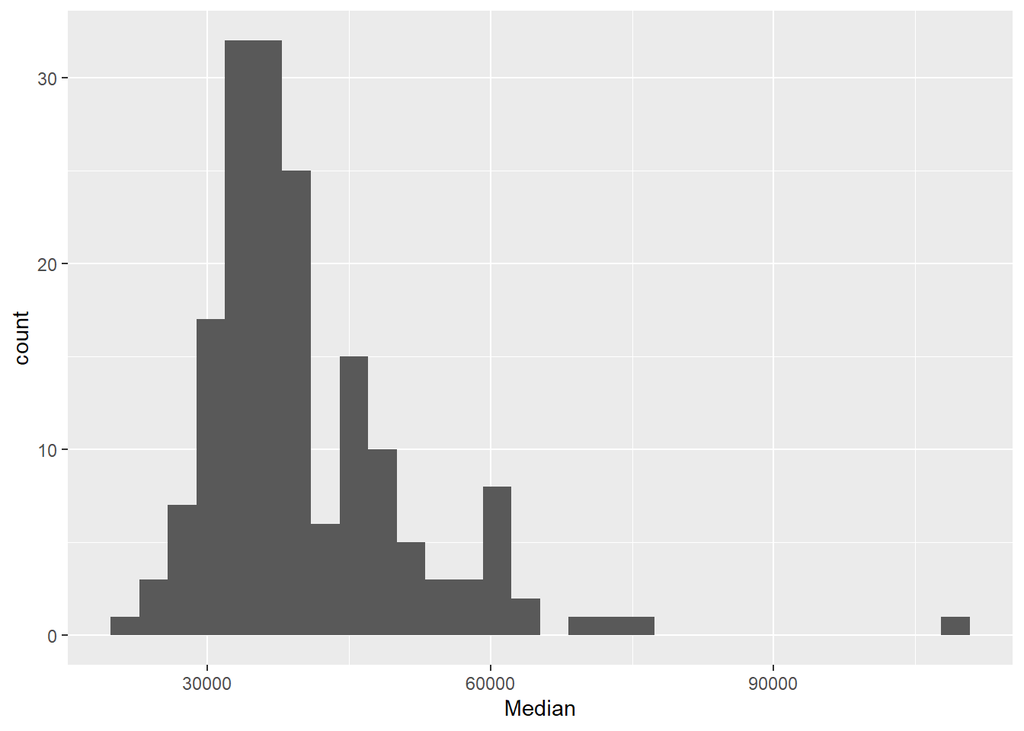

```r
# Viết code xử lý ở đây
ggplot(data = college_recent_grads) +
  geom_histogram(mapping = aes(x = Median))
```

#### **Câu 3.** Thay đổi `binwidth` của `histogram` với tham số `binwidth`. Thử các `binwidth` từ 1000 đến 10000 để vẽ lại `histogram` theo cú pháp `geom_histogram(binwidth = xxx)` và chọn `binwidth` bạn cho là phù hợp nhất. Giải thích sự lựa chọn của bạn.

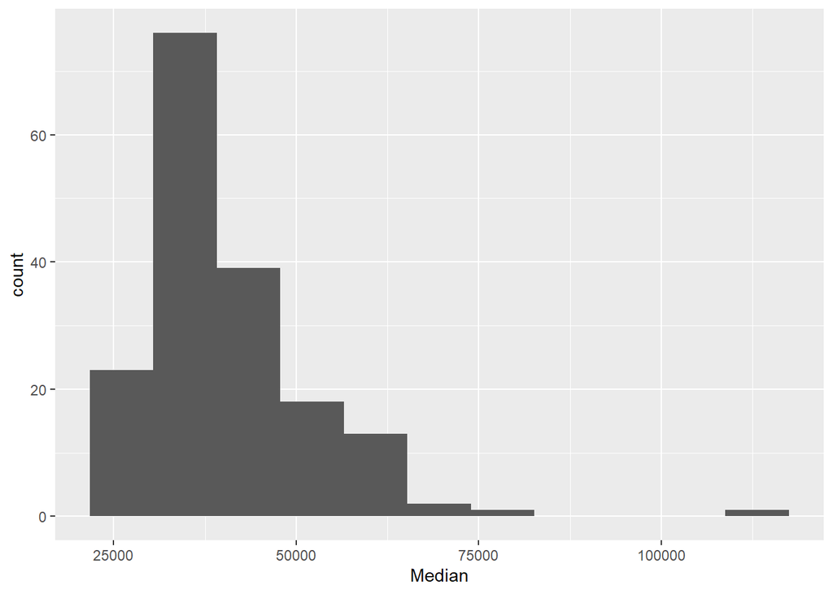

```r
# Viết code xử lý ở đây
bw <- 2 * IQR(college_recent_grads$Median) / length(college_recent_grads)^(1/3)
ggplot(data = college_recent_grads) +
  geom_histogram(mapping = aes(x = Median), binwidth = bw)
```

#### **Câu 4.** Vẽ phân bố của thu nhập trung vị (`Median`) theo nhóm nghành (`Major_category`) dùng `histogram` và `facet`.

- Ta có thể tính các thống kê mô tả cho phân bố thu nhập trung vị dùng hàm `summarise` như sau:

```r
college_recent_grads %>%
  summarise(min = min(Median), max = max(Median),
            mean = mean(Median), med = median(Median),
            sd = sd(Median),
            q1 = quantile(Median, probs = 0.25),
            q3 = quantile(Median, probs = 0.75))
```

```
##     min    max     mean   med       sd    q1    q3
## 1 22000 110000 40151.45 36000 11470.18 33000 45000
```

- Đoạn mã sau vẽ biểu đồ của `Median` và facet theo `Major_category`.

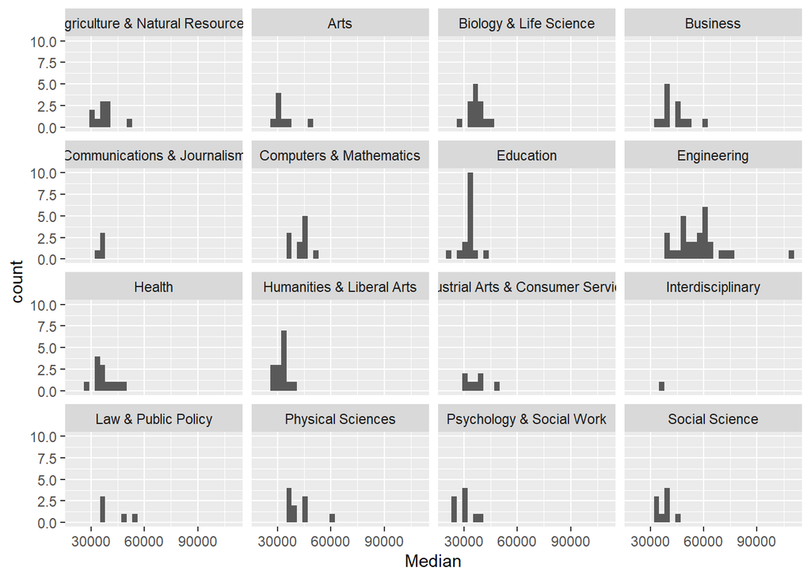

```r
ggplot(data = college_recent_grads, mapping = aes(x = Median)) +
  geom_histogram() +
  facet_wrap( ~ Major_category, ncol = 4)
```

```r
# Viết code xử lý ở đây
#college_recent_grads %>%
#  summarise(min = min(Median), max = max(Median),
#            mean = mean(Median), med = median(Median),
#            sd = sd(Median),
#            q1 = quantile(Median, probs = 0.25),
#            q3 = quantile(Median, probs = 0.75))
#ggplot(data = college_recent_grads) +
#  geom_histogram(mapping = aes(x = Median,
#                                y = Major_category)) +
#  facet_wrap( ~ Major_category, ncol = 4)
```

#### **Câu 5.** Nhóm ngành nào có thu nhập trung vị cao nhất?

- Sử dụng code mẫu bên dưới và điền vào những chỗ ___ các hàm thống kê phù hợp (bỏ `eval=FALSE` để hiển thị kết quả).

```r
college_recent_grads %>%
  group_by(Major_category) %>%
  summarise(___ = ___(Median)) %>%
  arrange(___)
```

```r
# Viết code xử lý ở đây
college_recent_grad <- college_recent_grads %>%
  group_by(Major_category) %>%
  summarise(Median = max(Median)) %>%
  arrange(desc(Median))
college_recent_grad
```

```
## # A tibble: 16 × 2
##    Major_category                      Median
##    <chr>                                <int>
##  1 Engineering                         110000
##  2 Business                             62000
##  3 Physical Sciences                    62000
##  4 Law & Public Policy                  54000
##  5 Agriculture & Natural Resources      53000
##  6 Computers & Mathematics              53000
##  7 Arts                                 50000
##  8 Industrial Arts & Consumer Services  50000
##  9 Health                               48000
## 10 Social Science                       47000
## 11 Biology & Life Science               45000
## 12 Education                            41000
## 13 Humanities & Liberal Arts            40000
## 14 Psychology & Social Work             40000
## 15 Communications & Journalism          35000
## 16 Interdisciplinary                    35000
```

#### **Câu 6.** Nhóm ngành nào ít phổ biến nhất?

- Sử dụng code mẫu bên dưới để thêm (phần …) vào các bước xử lý phù hợp (bỏ `eval=FALSE` để hiển thị kết quả).

```r
college_recent_grads %>%
  count(Major_category)
  ...
```

- Tạo một danh sách các nhóm ngành về `khoa học`, `công nghệ`, `kỹ thuật` và `Toán` (`STEM fields`) như sau:

```r
stem_categories <- c("Biology & Life Science",
                     "Computers & Mathematics",
                     "Engineering",
                     "Physical Sciences")
```

- Tạo một biến mới mô tả ngành học có thuộc nhóm ngành `STEM` hay không như sau:

```r
college_recent_grads <- college_recent_grads %>%
  mutate(major_type = ifelse(Major_category %in% stem_categories, "stem", "not stem"))
```

```r
# Viết code xử lý ở đây
college_recent_grads %>%
  count(Major_category)
```

```
##                         Major_category  n
## 1      Agriculture & Natural Resources 10
## 2                                 Arts  8
## 3               Biology & Life Science 14
## 4                             Business 13
## 5          Communications & Journalism  4
## 6              Computers & Mathematics 11
## 7                            Education 16
## 8                          Engineering 29
## 9                               Health 12
## 10           Humanities & Liberal Arts 15
## 11 Industrial Arts & Consumer Services  7
## 12                   Interdisciplinary  1
## 13                 Law & Public Policy  5
## 14                   Physical Sciences 10
## 15            Psychology & Social Work  9
## 16                      Social Science  9
```

#### **Câu 7.** Lọc ra các ngành học `STEM` có thu nhập trung vị bé hơn trung vị của thu nhập trung vị của tất cả các ngành.

- Sử dụng code mẫu bên dưới để thêm vào phần xử lý phù hợp (phần …). Kết quả chỉ hiển thị `tên ngành`, `Median`, `25th percentile`, và `75th percentile` thu nhập của ngành đó và sắp xếp `Median` theo thứ tự giảm dần. (bỏ `eval=FALSE` để hiển thị kết quả)

```r
college_recent_grads %>%
  filter(
    major_type == "stem",
    ...
  )
```

```r
# Viết code xử lý ở đây
college_recent_grads %>%
  filter(
    major_type == "stem",
    Median < median(Median)
  ) %>%
  arrange(desc(Median))%>%
  select(Major, Median, P25th,P75th,)
```

```
##                                    Major Median P25th P75th
## 1                  ENVIRONMENTAL SCIENCE  35600 25000 40200
## 2  MULTI-DISCIPLINARY OR GENERAL SCIENCE  35000 24000 50000
## 3                             PHYSIOLOGY  35000 20000 50000
## 4             COMMUNICATION TECHNOLOGIES  35000 25000 45000
## 5                           NEUROSCIENCE  35000 30000 44000
## 6   ATMOSPHERIC SCIENCES AND METEOROLOGY  35000 28000 50000
## 7                  MISCELLANEOUS BIOLOGY  33500 23000 48000
## 8                                BIOLOGY  33400 24000 45000
## 9                                ECOLOGY  33000 23000 42000
## 10                               ZOOLOGY  26000 20000 39000
```

#### **Câu 8.** Tạo một biểu đồ `scatterplot` của thu nhập (`Median`) với tỷ lệ sinh viên nữ của chuyên ngành đó, tô màu chuyên ngành có thuộc nhóm ngành `STEM` hay không. Mô tả mối quan hệ giữa ba biến này.

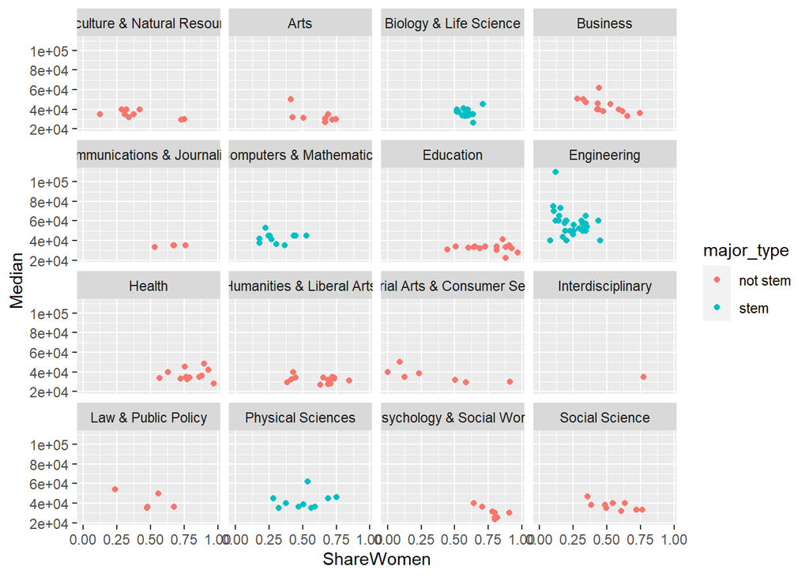

```r
# Viết code xử lý ở đây
ggplot(college_recent_grads)+
    geom_point(mapping = aes(x = ShareWomen , y = Median, color = major_type))+
        facet_wrap( ~ Major_category, ncol=4)
```